# Practical Machine Learning

Marcus Turnbo

May 22, 2015

## Executive Summary

Using devices such as Jawbone Up, Nike FuelBand, and Fitbit it is now possible to collect a large amount of data about personal activity relatively inexpensively. These type of devices are part of the quantified self movement – a group of enthusiasts who take measurements about themselves regularly to improve their health, to find patterns in their behavior, or because they are tech geeks. One thing that people regularly do is quantify how much of a particular activity they do, but they rarely quantify how well they do it. Our goal is to use data from accelerometers on the belt, forearm, arm, and dumbell of 6 participants. They were asked to perform barbell lifts correctly and incorrectly in 5 different ways.

## Loading Data

Download the training and test data for this analysis. Read the CSV files into data tables.

```r
if (!file.exists('pml-training.csv')) {
    download.file('https://d396qusza40orc.cloudfront.net/predmachlearn/pml-training.csv', destfile='pml-training.csv', method='curl')
}
if (!file.exists('pml-testing.csv')) {
    download.file('https://d396qusza40orc.cloudfront.net/predmachlearn/pml-testing.csv', destfile='pml-testing.csv', method='curl')
}
pmlTraining <- read.table('pml-training.csv', sep=',', header=TRUE)
pmlTesting <- read.table('pml-testing.csv', sep=',', header=TRUE)
```

## Cleaning Data

Use the fields that have the data relevant for the weight-lifting study.

```r
# get subset of fields
namesSubset <- grep("classe|(^roll|^pitch|^yaw|^total_accel|^gyros|^accel|^magnet).*(_belt|_forearm|_arm|_belt|_dumbbell)", names(pmlTraining), value=T)
pmlTrainingQualified <- subset(pmlTraining, select=namesSubset)
pmlTrainingQualified$classe <- factor(pmlTrainingQualified$classe)
# sapply(pmlTrainingQualified, function(x) is.factor(x))

namesSubset <- grep("classe|(^roll|^pitch|^yaw|^total_accel|^gyros|^accel|^magnet).*(_belt|_forearm|_arm|_belt|_dumbbell)", names(pmlTesting), value=T)
pmlTestingQualified <- subset(pmlTesting, select=namesSubset)
```

## Data Partitioning

We have narrowed the training set down to 53 variables. We will split that into 2 sets: 70% into a training set and 30% into a test set.

```r
library(caret)
set.seed(1973)
inTrain <- createDataPartition(y=pmlTrainingQualified$classe, p=0.7, list=FALSE)
training <- pmlTrainingQualified[inTrain,]
testing <- pmlTrainingQualified[-inTrain,]
```

## Machine Learning Models

```r
# LDA
modelLDA <- train(classe ~ ., method='lda', data=training)
prediction <- predict(modelLDA, testing)
cm <- confusionMatrix(prediction, testing$classe)
accuracyLDA <- cm$overall['Accuracy']
accuracyLDA

# RF
modelRF <- train(classe ~ ., method='rf', data=training)
prediction <- predict(modelRF, testing)
cm <- confusionMatrix(prediction, testing$classe)
accuracyRF <- cm$overall['Accuracy']

# GBM
modelGBM <- train(classe ~ ., method='gbm', data=training)
prediction <- predict(modelGBM, testing)
cm <- confusionMatrix(prediction, testing$classe)
accuracyGBM <- cm$overall['Accuracy']
```

[output not shown]

## Cross Validation

```r
set.seed(1973)
controlf <- trainControl(method='repeatedcv', number=10, repeats=10)
modelRFCV <- train(classe ~ ., method="rf",  data=training, trControl=controlf)
```

## Evaluate the Test Data

```r
prediction <- predict(modelRFCV, testing)
prediction
cm <- confusionMatrix(prediction, testing$classe)
accuracyRF <- cm$overall['Accuracy']
```

```r
print(cm)
```

[output not shown]

## Appendix

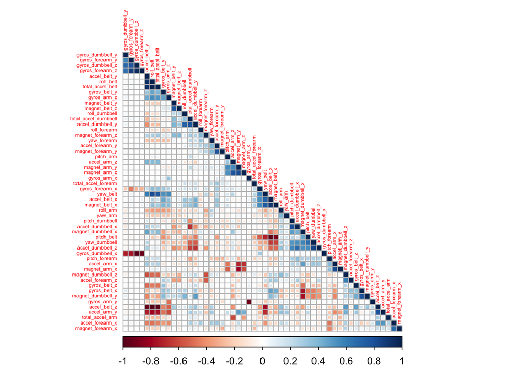

```r
# correlation
library(corrplot)
par(mar=rep(0,4))
M <- cor(training[,-53])
corrplot(M, type='lower', method='square', order='hclust', tl.cex=.4)
```